Skip to content

# Generate CMEMS data cubes

**A DeepESDL example notebook**

This notebook demonstrates how to access CMEMS data via the dedicated xcube store, which provides dynamic data cube views into each gridded data set. More information on the data sets offered can be found in the [Copernicus Marine Data Store](https://data.marine.copernicus.eu/products).

Please, also refer to the [DeepESDL documentation](https://earthsystemdatalab.net/guide/jupyterlab) and visit the platform's [website](https://www.earthsystemdatalab.net/) for further information!

Brockmann Consult, 2025

**This notebook runs with the python environment `users-deepesdl-xcube-1.9.1`, please checkout the documentation for [help on changing the environment](https://earthsystemdatalab.net/guide/jupyterlab/#python-environment-selection-of-the-jupyter-kernel).**

If you do not have cmems user yet, you can register for an [account](https://resources.marine.copernicus.eu/registration-form). For DeepESDL Basic Jupyter Profile default credentials are configured, but due to bandwith limitation by CMEMS they might not be performant when used by several people simultanously.

```python
# mandatory imports
import datetime

import matplotlib.pyplot as plt

# Utilities for notebook visualization
import shapely.geometry
from IPython.display import JSON
from xcube.core.store import (
    find_data_store_extensions,
    get_data_store_params_schema,
    new_data_store,
)
```

# mandatory imports import datetime import matplotlib.pyplot as plt # Utilities for notebook visualization import shapely.geometry from IPython.display import JSON from xcube.core.store import ( find_data_store_extensions, get_data_store_params_schema, new_data_store, )

```python
import xcube_cmems
```

import xcube_cmems

```python
xcube_cmems.__version__
```

xcube_cmems.__version__

```
'0.1.6'
```

```python
import os
```

import os

```python
## replace with your user name and pwd
# os.environ["CMEMS_USERNAME"] = "<your-username>"
# os.environ["CMEMS_PASSWORD"] = "<your-pwd>"
```

## replace with your user name and pwd # os.environ["CMEMS_USERNAME"] = "" # os.environ["CMEMS_PASSWORD"] = ""

```python
JSON({e.name: e.metadata for e in find_data_store_extensions()})
```

[output not shown]

JSON({e.name: e.metadata for e in find_data_store_extensions()})

Usually we need more information to get the actual data store object. Which data store parameters are available for `cmems`?

```python
get_data_store_params_schema("cmems")
```

get_data_store_params_schema("cmems")

```
<xcube.util.jsonschema.JsonObjectSchema at 0x7f1313c4b110>
```

#### Import the xcube CMEMS store and create store instance

If you do not have cmems user yet, you can register for an [account](https://resources.marine.copernicus.eu/registration-form). For DeepESDL Basic Jupyter Profile default credentials are configured, but due to bandwith limitation by CMEMS they might not be performant when used by several people simultanously.

```python
# cmems_store = new_data_store('cmems', cmems_username=os.environ["CMEMS_USERNAME"], cmems_password = os.environ["CMEMS_PASSWORD"])
cmems_store = new_data_store("cmems")
```

# cmems_store = new_data_store('cmems', cmems_username=os.environ["CMEMS_USERNAME"], cmems_password = os.environ["CMEMS_PASSWORD"]) cmems_store = new_data_store("cmems")

#### Get all dataset_ids for CMEMS API and let store describe data set

```python
#cmems_store.list_data_ids()
```

#cmems_store.list_data_ids()

```python
data_des = cmems_store.describe_data("cmems_mod_bal_wav_my_PT1H-i")
```

data_des = cmems_store.describe_data("cmems_mod_bal_wav_my_PT1H-i")

```
INFO - 2025-06-10T09:28:41Z - Selected dataset version: "202411"
INFO - 2025-06-10T09:28:41Z - Selected dataset part: "default"
```

```python
data_des.time_range
```

data_des.time_range

```
('1980-01-01', '2025-03-01')
```

```python
data_des.bbox
```

data_des.bbox

```
(9, 53, 30.221627251342774, 65.91610912890626)
```

#### Open a dataset without cube parameters

```python
ds = cmems_store.open_data("cmems_mod_bal_wav_my_PT1H-i")
ds
```

ds = cmems_store.open_data("cmems_mod_bal_wav_my_PT1H-i") ds

```
INFO - 2025-06-10T09:28:50Z - Selected dataset version: "202411"
INFO - 2025-06-10T09:28:50Z - Selected dataset part: "default"
```

```
<xarray.Dataset> Size: 18TB
Dimensions:    (time: 395904, latitude: 775, longitude: 764)
Coordinates:
  * latitude   (latitude) float32 3kB 53.01 53.02 53.04 ... 65.87 65.89 65.91
  * longitude  (longitude) float32 3kB 9.014 9.042 9.069 ... 30.15 30.18 30.21
  * time       (time) datetime64[ns] 3MB 1980-01-01T01:00:00 ... 2025-03-01
Data variables: (12/19)
    VCMX       (time, latitude, longitude) float32 938GB dask.array<chunksize=(2, 775, 764), meta=np.ndarray>
    VHM0       (time, latitude, longitude) float32 938GB dask.array<chunksize=(2, 775, 764), meta=np.ndarray>
    VHM0_SW1   (time, latitude, longitude) float32 938GB dask.array<chunksize=(2, 775, 764), meta=np.ndarray>
    VHM0_SW2   (time, latitude, longitude) float32 938GB dask.array<chunksize=(2, 775, 764), meta=np.ndarray>
    VHM0_WW    (time, latitude, longitude) float32 938GB dask.array<chunksize=(2, 775, 764), meta=np.ndarray>
    VMDR       (time, latitude, longitude) float32 938GB dask.array<chunksize=(2, 775, 764), meta=np.ndarray>
    ...         ...
    VTM01_SW1  (time, latitude, longitude) float32 938GB dask.array<chunksize=(2, 775, 764), meta=np.ndarray>
    VTM01_SW2  (time, latitude, longitude) float32 938GB dask.array<chunksize=(2, 775, 764), meta=np.ndarray>
    VTM01_WW   (time, latitude, longitude) float32 938GB dask.array<chunksize=(2, 775, 764), meta=np.ndarray>
    VTM02      (time, latitude, longitude) float32 938GB dask.array<chunksize=(2, 775, 764), meta=np.ndarray>
    VTM10      (time, latitude, longitude) float32 938GB dask.array<chunksize=(2, 775, 764), meta=np.ndarray>
    VTPK       (time, latitude, longitude) float32 938GB dask.array<chunksize=(2, 775, 764), meta=np.ndarray>
Attributes:
    institution:  Baltic MFC, PU Finnish Meteorological Institute
    title:        2D - Hourly Instantaneous
    Conventions:  CF-1.0
    source:       FMI-WAM_CMEMS
```

```python
ds.VHM0
```

ds.VHM0

```
<xarray.DataArray 'VHM0' (time: 395904, latitude: 775, longitude: 764)> Size: 938GB
dask.array<xarray-VHM0, shape=(395904, 775, 764), dtype=float32, chunksize=(2, 775, 764), chunktype=numpy.ndarray>
Coordinates:
  * latitude   (latitude) float32 3kB 53.01 53.02 53.04 ... 65.87 65.89 65.91
  * longitude  (longitude) float32 3kB 9.014 9.042 9.069 ... 30.15 30.18 30.21
  * time       (time) datetime64[ns] 3MB 1980-01-01T01:00:00 ... 2025-03-01
Attributes:
    cell_methods:   time: mean
    long_name:      Spectral significant wave height (Hm0)
    standard_name:  sea_surface_wave_significant_height
    units:          m
    valid_max:      20.0
    valid_min:      0.0
```

```python
ds.VHM0.isel(time=0).plot.imshow()
```

ds.VHM0.isel(time=0).plot.imshow()

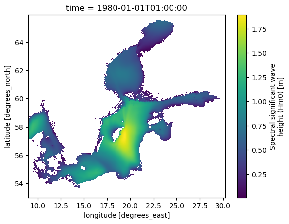

#### Open a dataset with cube parameters

```python
cmems_store.get_open_data_params_schema(
    "cmems_mod_bal_wav_my_PT1H-i"
)
```

cmems_store.get_open_data_params_schema( "cmems_mod_bal_wav_my_PT1H-i" )

```
<xcube.util.jsonschema.JsonObjectSchema at 0x7fa72fe22630>
```

```python
ds = cmems_store.open_data(
    "cmems_mod_bal_wav_my_PT1H-i",
    variable_names=["VHM0"],
    time_range=("2021-11-01", "2021-12-13"),
    bbox=[10, 54, 20, 62]
)
ds
```

ds = cmems_store.open_data( "cmems_mod_bal_wav_my_PT1H-i", variable_names=["VHM0"], time_range=("2021-11-01", "2021-12-13"), bbox=[10, 54, 20, 62] ) ds

```
INFO - 2025-06-10T09:29:06Z - Selected dataset version: "202411"
INFO - 2025-06-10T09:29:06Z - Selected dataset part: "default"
```

```
<xarray.Dataset> Size: 697MB
Dimensions:    (time: 1009, latitude: 480, longitude: 360)
Coordinates:
  * latitude   (latitude) float32 2kB 54.01 54.02 54.04 ... 61.96 61.97 61.99
  * longitude  (longitude) float32 1kB 10.01 10.04 10.07 ... 19.93 19.96 19.99
  * time       (time) datetime64[ns] 8kB 2021-11-01 ... 2021-12-13
Data variables:
    VHM0       (time, latitude, longitude) float32 697MB dask.array<chunksize=(2, 480, 360), meta=np.ndarray>
Attributes:
    institution:  Baltic MFC, PU Finnish Meteorological Institute
    title:        2D - Hourly Instantaneous
    Conventions:  CF-1.0
    source:       FMI-WAM_CMEMS
```

```python
ds.VHM0.sel(time="2021-12-13T12:12.00", method="nearest").plot.imshow()
```

ds.VHM0.sel(time="2021-12-13T12:12.00", method="nearest").plot.imshow()

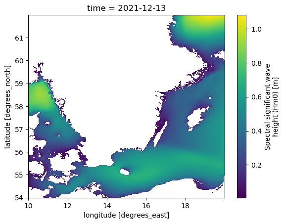